# Homework 6

your-name-here

## Problem #1: Estimating Quantiles (8 pts; 2pts each)

There are 9 algorithms in R to estimate population quantiles. Type `?quantile` to read about them. Here we will investigate the variance of some of these estimators. To use the quantile function you use the syntax `quantile(vector, probs, type)`. For example if you have data in a vector called `sampleData` and you wish to estimate the 80th percentile using algorithm 7 (the default), you use `quantile(sampleData, .80, type=7)`

Suppose we’re interested in the 95th percentile for $X$, and we know that $X$ follows a uniform distribution. We want to randomly sample $n=30$ values and estimate the 95th percentile. Using MC simulation estimate the following:

1. Which quantile algorithm (4 through 9 has the smallest absolute bias? *Hint: you can use $unif(0,1)$ for the purposes of this estimation, as your answer won’t depend on the upper and lower bounds chosen.*
2. Which quantile algorithm (4 through 9) has the smallest variance?
3. Which method is best for estimating the 95th percentile from a uniform distribution? Justify your answer.
4. What about if $X\sim N(\mu, \sigma^2)$? Would you prefer a different method for estimating the 95th percentile from a normal distribution? *Hint: repeat the same analysis for $N(0,1)$.*

> SOLUTION

> ```r
> types <- 4:9
> bias <- types
> variance <- types
> results <- data.frame(types, bias, variance)
>
> #95th percentile estimation
> p <- .95
> NMC <- 10000
> for(i in 1:nrow(results)){
>   quantiles <- replicate(NMC, quantile(runif(30,0,100),.95,type=results$types[i]))
>   results$bias[i] <- mean(quantiles)-95
>   results$variance[i] <- var(quantiles)
> }
> results
> ```

> ```
> ##   types        bias variance
> ## 1     4 -3.07367962 20.85943
> ## 2     5 -1.33617373 17.98079
> ## 3     6  0.03553156 12.02511
> ## 4     7 -2.90192329 20.46691
> ## 5     8 -1.03705684 16.05845
> ## 6     9 -1.06517650 17.34509
> ```

> When estimating the 95th percentile from a Uniform, Method 6 has the smallest absolute bias. Method 6 also has the smallest variance. For those two reasons Method 6 would be preferred when estimating the 95th percentile from a uniform distribution.

> ```r
> results <- data.frame(types, bias, variance)
>
> #95th percentile estimation
> p <- .95
> NMC <- 10000
> for(i in 1:nrow(results)){
>   quantiles <- replicate(NMC, quantile(rnorm(30),.95,type=results$types[i]))
>   results$bias[i] <- mean(quantiles)-qnorm(.95)
>   results$variance[i] <- var(quantiles)
> }
> results$mse = results$bias^2 + results$variance
> results
> ```

> ```
> ##   types        bias  variance       mse
> ## 1     4 -0.15757520 0.1061636 0.1309936
> ## 2     5 -0.03123960 0.1343269 0.1353028
> ## 3     6  0.15352602 0.1511172 0.1746875
> ## 4     7 -0.14088254 0.1089446 0.1287925
> ## 5     8  0.03303287 0.1343483 0.1354394
> ## 6     9  0.02519255 0.1350412 0.1356759
> ```

## Problem #2: Estimating a Geometric $p$ (6 pts; 2 pts each)

1. Use the method of moments to come up with an estimator for a geometric distributions parameter $p$. *Hint: Use the fact that if $X\sim Geom(p)$ then $EX=\frac{1-p}{p}$.
2. Estimate the sampling distribution of this estimator when we sample $n=13$ values from from $Geom(.15)$. Show the histogram of the estimated sampling distribution.
3. Estimate the bias of this estimator. Is it biased? If it is biased how would you modify it so that you could create an unbiased estimator?

> SOLUTION
> 1. Since $\bar{X} = EX$, we could argue that $\bar{x} \approx \frac{1-p}{p}= \frac{1}{p}-1$ Thus $p \approx \frac{1}{\bar{X}+1}$

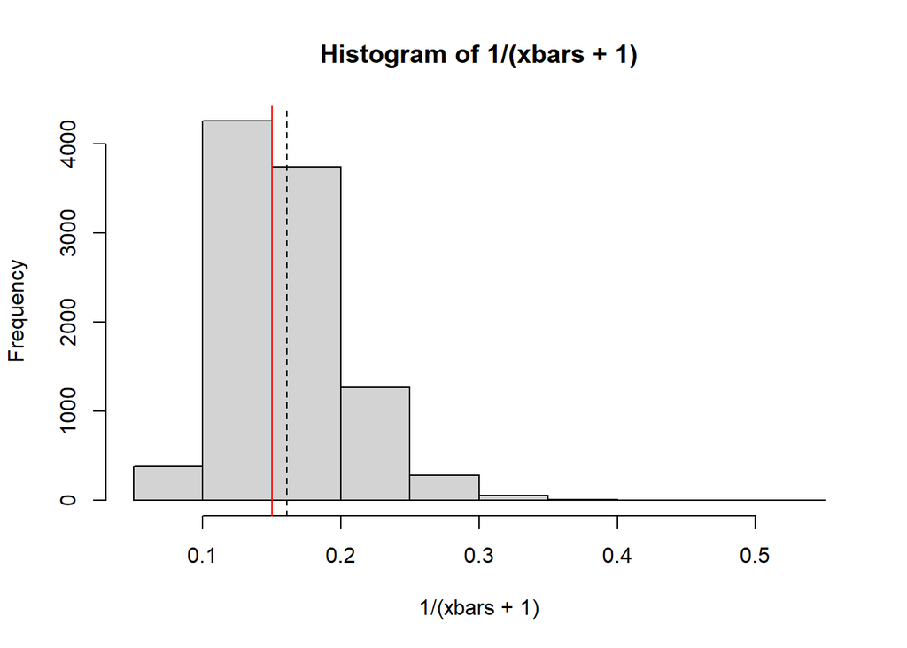

> ```r
> xbars <- replicate(10000, mean(rgeom(13, .15)))
> hist(1/(xbars+1))
> abline(v=.15, col="red")
> abline(v=mean(1/(xbars+1)), lty=2)
> ```

> ```r
> mean(1/(xbars+1)) - .15
> ```

> ```
> ## [1] 0.01083915
> ```

> $$\hat{\theta} =
> \dfrac{1-1/n}{\bar{X}+1-1/n}$$
> Let’s just see if this is an unbiased estimate!

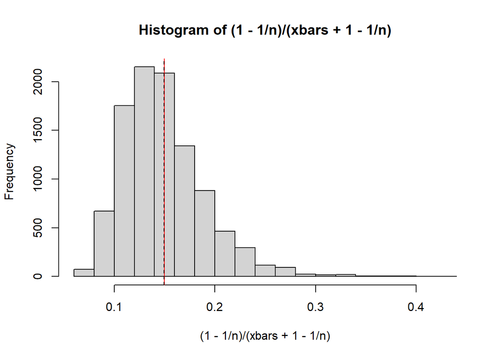

> ```r
> n=13; p=.15
> xbars <- replicate(10000, mean(rgeom(n, p)))
> hist((1-1/n)/(xbars+1-1/n))
> abline(v=.15, col="red")
> abline(v=mean((1-1/n)/(xbars+1-1/n)), lty=2)
> ```

## Problem #3: Estimating $\lambda$ from a Poisson Distribution(8 pts; 2 pts each)

It is interesting that if $X\sim Pois(\lambda)$ that $EX=VarX=\lambda$. One could use either $\bar{X}$ or $S^2$ as an estimator of $\lambda$ perhaps.

1. Using $n=15$ and $\lambda=20$ for this problem, use MC simulation to estimate the sampling distribution of The estimator $\bar{X}$. Show its histogram.
2. Repeat the same but this time use $S^2$.
3. Compare the two estimators. Would you prefer one over the other? Why?
4. What about a linear combination of the two variables? Could you construct an estimator of $\lambda$ of the form $a\bar{X} + bS^2$ that would be better than using either of them by themselves?

> SOLUTION

> ```r
> xbars <- 0
> s2s <- 0
> for(i in 1:10000){
>   poisSample <- rpois(15, 20)
>   xbars[i] <- mean(poisSample)
>   s2s[i] <- var(poisSample)
> }
> ```

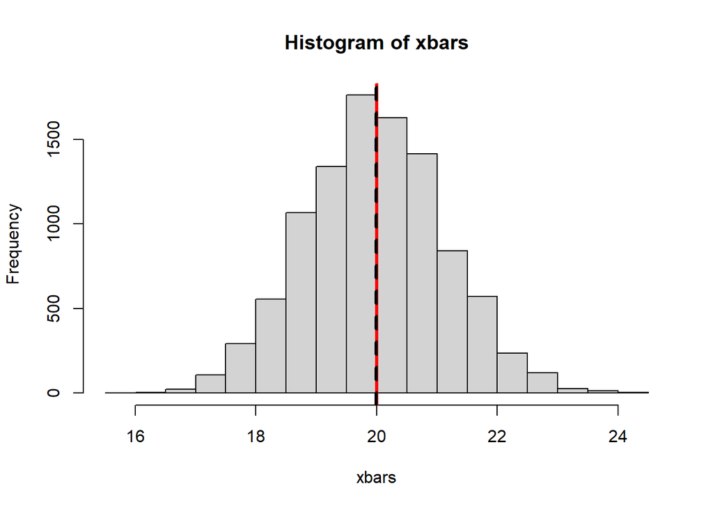

> ```r
> hist(xbars)
> abline(v=20, col="red", lwd=3)
> abline(v=mean(xbars), lty=2, lwd=3)
> ```

> ```r
> mean(xbars)
> ```

> ```
> ## [1] 19.98967
> ```

> ```r
> var(xbars)
> ```

> ```
> ## [1] 1.323862
> ```

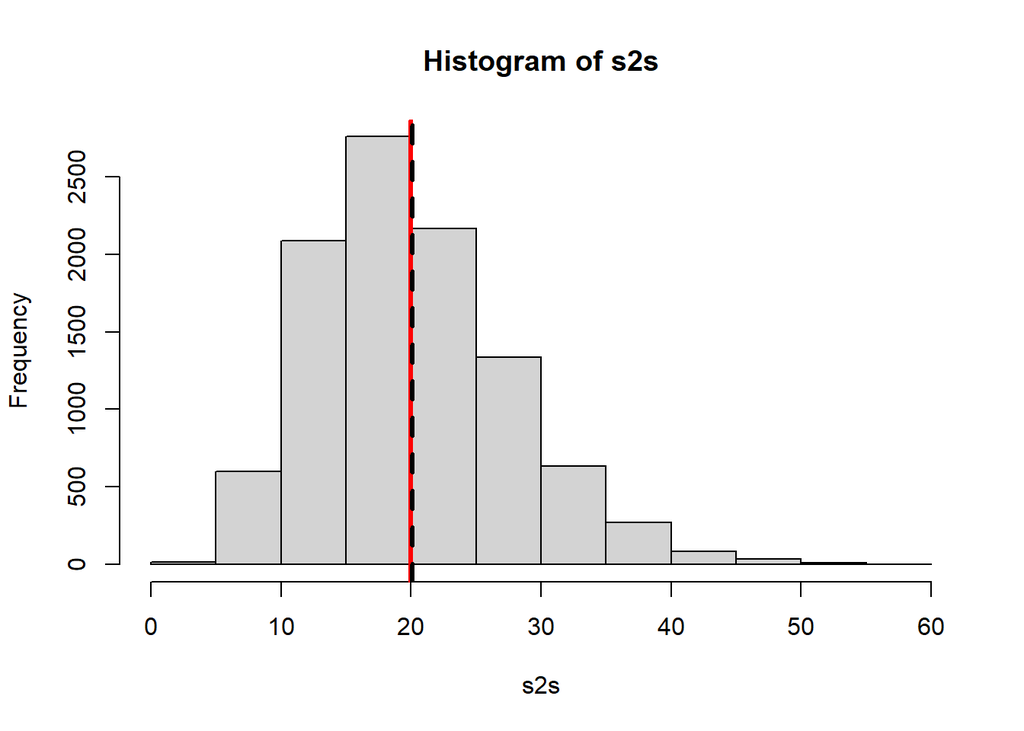

> ```r
> hist(s2s)
> abline(v=20, col="red", lwd=3)
> abline(v=mean(s2s), lwd=3, lty=2)
> ```

> ```r
> mean(s2s)
> ```

> ```
> ## [1] 20.12928
> ```

> ```r
> var(s2s)
> ```

> ```
> ## [1] 56.83234
> ```

> Both estimators seem to be unbiased. But $\bar{X}$ has a much lower variance. It would be preferred to using $S^2$.

> As far as a linear combination goes, it would only make sense if the two estimators had a negative covariance. But

> ```r
> cov(xbars, s2s)
> ```

> ```
> ## [1] 1.335921
> ```

> They have a positive covariance. Consider unbiased estimators of the form $a\bar{X}+(1-a)S^2$

> ```r
> for(a in seq(0,1,.1)){
>  cat(paste(a, mean(a*xbars + (1-a)*s2s), var(a*xbars + (1-a)*s2s)), "\n")
> }
> ```

> ```
> ## 0 20.1292828571429 56.8323408504034
> ## 0.1 20.1153219047619 46.2879005152724
> ## 0.2 20.101360952381 36.8531473856311
> ## 0.3 20.0874 28.5280814614795
> ## 0.4 20.073439047619 21.3127027428176
> ## 0.5 20.0594780952381 15.2070112296454
> ## 0.6 20.0455171428571 10.2110069219629
> ## 0.7 20.0315561904762 6.32468981977018
> ## 0.8 20.0175952380952 3.54805992306714
> ## 0.9 20.0036342857143 1.8811172318538
> ## 1 19.9896733333333 1.32386174613017
> ```

> Clearly using $\bar{X}$ by itself is better than any linear combination of the two estimators.

## Problem #4: The Standard Error of $\bar{X}$(8 pts; 2 pts each)

What would be the required sample size $n$ so that the standard error of $\bar{X}$ (i.e. $SD(\bar{X})$) would be 2 (or just under 2) for the following populations:

1. $Normal(1000, 10^2)$
2. $Pois(75)$
3. $Binom(200, .35)$
4. $exp(.05)$

> SOLUTION